# Human Airway Smooth Muscle Cell Responses to Asthma Medications

Taylor DiMenna

2026-09-15

# Human Airway Smooth Muscle Cell Responses to Asthma Medications

This assignment is using the GEO GSE52778 (airway RNA-seq) dataset. This dataset contains RNA sequencing data from human airway smooth muscle cells under four different asthma treatment conditions: treated with Dexamethasone, Albuterol, left untreated, or treated with both Dexamethasone + Albuterol.

## Research Question

How do different asthma treatments affect gene expression in human airway smooth muscle cells?

## Load Packages

```r
library(readr)
library(dplyr)
```

```r
library(ggplot2)
```

## Load Data

```r
url <- "https://www.ncbi.nlm.nih.gov/geo/download/?acc=GSE52778&format=file&file=GSE52778_All_Sample_FPKM_Matrix.txt.gz"

fpkm <- read_table(
  url,
  show_col_types = FALSE
)

dim(fpkm)
```

```
## [1] 23273    41
```

## Select Sample Columns

```r
sample_columns <- c(
  "Dex_LL14",
  "Dex_LL06",
  "Dex_LL02",
  "Dex_LL10",
  "Alb_LL07",
  "Alb_LL03",
  "Alb_LL11",
  "Alb_LL15",
  "Untreated_LL09",
  "Untreated_LL05",
  "Untreated_LL13",
  "Untreated_LL01",
  "Alb_Dex_LL08",
  "Alb_Dex_LL04",
  "Alb_Dex_LL12",
  "Alb_Dex_LL16"
)

expression <- fpkm %>%
  select(all_of(sample_columns))

dim(expression)
```

```
## [1] 23273    16
```

## Log2 Transformation

A log transformation was done (took the log base 2) of each gene expression value to compress the scale of the data and make them more balanced, so extremely large values didn’t have a large influence on the final results

```r
log_expression <- expression %>%
  mutate(across(everything(), ~log2(.x + 1)))

dim(log_expression)
```

```
## [1] 23273    16
```

## Prepare Data for PCA

```r
expression_for_pca <- t(as.matrix(log_expression))

dim(expression_for_pca)
```

```
## [1]    16 23273
```

## PCA

PCA is used to explore whether the samples receiving different asthma treatments showed differences in their overall gene expression.

```r
pca <- prcomp(
  expression_for_pca,
  center = TRUE,
  scale. = FALSE
)

summary(pca)
```

```
## Importance of components:
##                            PC1     PC2     PC3     PC4      PC5      PC6
## Standard deviation     29.1523 22.4584 20.7580 19.5538 17.25954 16.51952
## Proportion of Variance  0.2187  0.1298  0.1109  0.0984  0.07667  0.07023
## Cumulative Proportion   0.2187  0.3485  0.4594  0.5578  0.63450  0.70473
##                             PC7      PC8      PC9     PC10     PC11     PC12
## Standard deviation     14.34358 13.50037 12.26997 11.46701 10.96418 10.03568
## Proportion of Variance  0.05295  0.04691  0.03875  0.03384  0.03094  0.02592
## Cumulative Proportion   0.75768  0.80459  0.84334  0.87718  0.90812  0.93404
##                           PC13    PC14    PC15      PC16
## Standard deviation     9.98074 9.53416 8.11035 8.434e-14
## Proportion of Variance 0.02564 0.02339 0.01693 0.000e+00
## Cumulative Proportion  0.95968 0.98307 1.00000 1.000e+00
```

## PCA Variance Explained

```r
pca_variance <- (pca$sdev^2) / sum(pca$sdev^2)

pca_variance[1:2]
```

```
## [1] 0.2187228 0.1298101
```

## Prepare PCA Results

```r
pca_df <- as.data.frame(pca$x[, 1:2])

pca_df$Sample <- rownames(pca_df)

metadata <- data.frame(
  Sample = sample_columns,
  Treatment = c(
    "Dexamethasone",
    "Dexamethasone",
    "Dexamethasone",
    "Dexamethasone",
    "Albuterol",
    "Albuterol",
    "Albuterol",
    "Albuterol",
    "No treatment",
    "No treatment",
    "No treatment",
    "No treatment",
    "Dexamethasone + Albuterol",
    "Dexamethasone + Albuterol",
    "Dexamethasone + Albuterol",
    "Dexamethasone + Albuterol"
  )
)

pca_df <- pca_df %>%
  left_join(metadata, by = "Sample")

dim(pca_df)
```

```
## [1] 16  4
```

## PCA

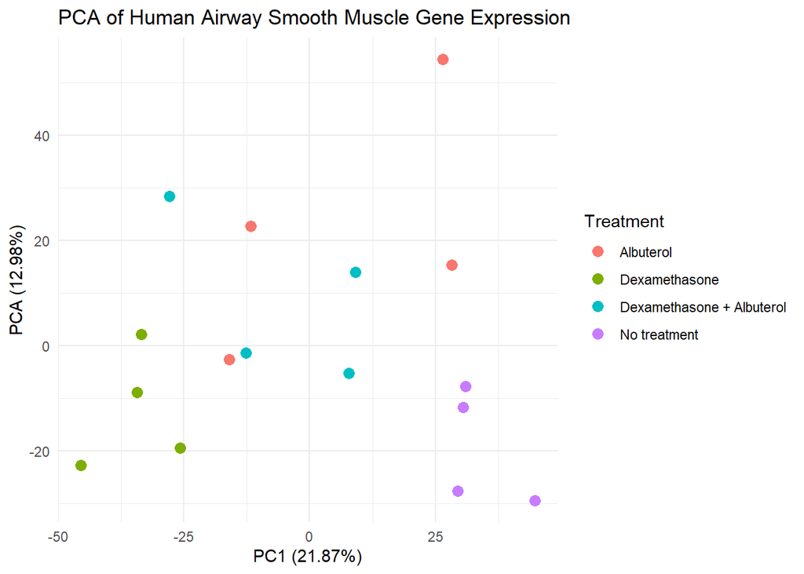

```r
ggplot(pca_df, aes(x = PC1, y = PC2, color = Treatment)) +
  geom_point(size = 3) +
  labs(
    title = "PCA of Human Airway Smooth Muscle Gene Expression",
    x = paste0("PC1 (", round(pca_variance[1] * 100, 2), "%)"),
    y = paste0("PCA (", round(pca_variance[2] * 100, 2), "%)"),
    color = "Treatment"
  ) +
  theme_minimal()
```

## Interpretation of the Result According to the PCA, both the gene expression of Dexamethasone treated samples and untreated samples showed little variation in gene expression, and clearly differed from each other along PC1. The Albuterol and Dexamethasone + Albuterol treated samples, however, showed greater variation in gene expression and less distinct clustering. Overall, these results suggest that different asthma treatments can be associated with differences in gene expression patterns in human airway smooth muscle cells.

## Graduate Addendum

Comparing the two implementations I used to create these notebooks, I believe that the R notebook was easier to write. This is not because I have more knowledge on how to write in R, but rather because it was a lot faster to write the R notebook since I already completed the majority of the work within the Jupyter notebook. I only had to translate the contents of that notebook over to R, which made it a lot faster. Although it took more time to write the Jupyter notebook, I would trust that implementation more. This is because I have more experience in Python, so I simply feel more comfortable with it.